# Introduction to Network Analysis

### 4.2 Degree Centrality

Degree centrality is simple: Recall that the **degree** of a node is the number of nodes directly connected to it. In degree centrality, the more adjacent nodes, the more important the network is considered to be. Degree centrality is used primarily in social networks, where nodes with higher degrees are commonly major channels of information. A high degree means a node has many direct ties with other nodes, and has better access to resources within the network.

Note that the NetworkX `nx.degree_centrality()` function normalizes each node’s degree by dividing by the maximum possible degree in the network. Therefore for graphs without self-loops the degree centrality is always $\leq 1$. For educational purposes, we un-normalize the degree values, but this is not common practice.

We can not use the same random graph technique as each node will have a degree equal to 3, instead we will use the first graph from this notebook.

We can calculate the degree centrality of all our nodes in our network:

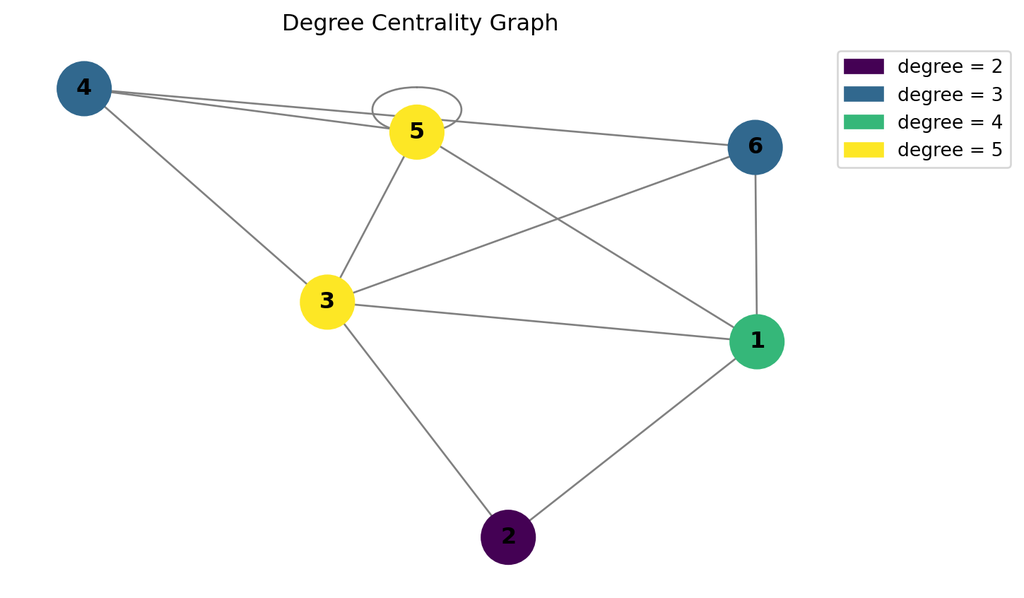

```python
# Define the graph
nodes = (1, 2, 3, 4, 5, 6)
edges = [
    (1, 2), (2, 3), (3, 1), (1, 5), (3, 5),
    (4, 5), (4, 6), (6, 1), (6, 3), (6, 4),
    (4, 3), (5, 5), (3, 5)
]
G = nx.Graph()
G.add_edges_from(edges)
G.add_nodes_from(nodes)

# Get degree for each node
degree_dict = dict(G.degree())
degrees = list(degree_dict.values())
unique_degrees = sorted(set(degrees))

# Assign a unique color per degree
colors = plt.get_cmap('viridis', len(unique_degrees))
degree_to_color = {deg: colors(i) for i, deg in enumerate(unique_degrees)}
color_map = [degree_to_color[degree_dict[n]] for n in G.nodes()]

# Create legend for each degree
patches = [mpatches.Patch(color=colors(i), label=f"degree = {deg}") for i, deg in enumerate(unique_degrees)]

plt.figure(figsize=(6, 4))
nx.draw(G, with_labels=True, node_color=color_map, node_size=800, edge_color='gray', font_weight='bold')
plt.legend(handles=patches, bbox_to_anchor=(1, 1))
plt.title("Degree Centrality Graph")
plt.tight_layout()
plt.show()
```

### 4.3 Closeness Centrality

**Closeness centrality** is a measure of how close a node is to all other nodes in the network. It can be computed as the “sum of the geodesic distances of a node to all other nodes in the network”. A node is *important* if it is *close to all other nodes in the network*. One flaw of closeness centrality is that while it is a useful indicator of node importance in small networks, it produces little variation in large networks with many edges.

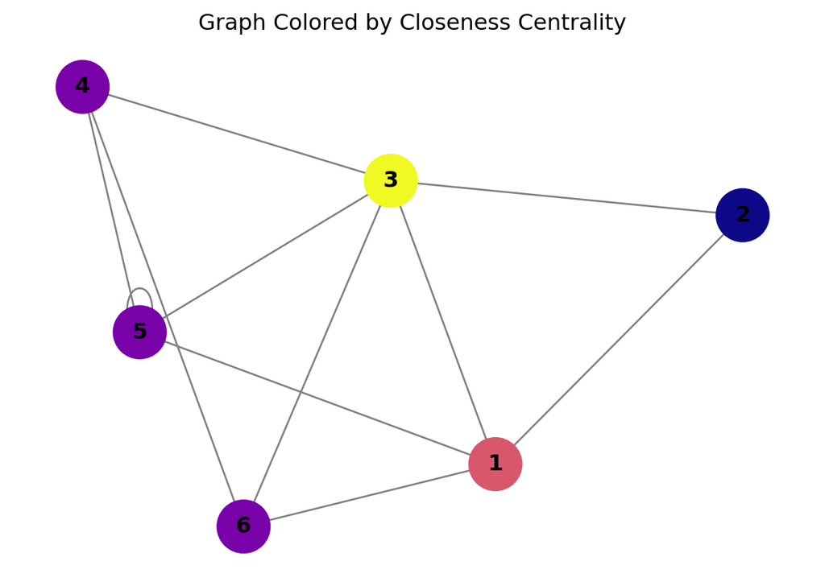

```
Node    Closeness Centrality
1   0.8333
2   0.6250
3   1.0000
5   0.7143
4   0.7143
6   0.7143
```

```python
# Define the graph
nodes = (1, 2, 3, 4, 5, 6)
edges = [(1, 2), (2, 3), (3, 1), (1, 5), (3, 5),(4, 5), (4, 6), (6, 1), (6, 3), (6, 4),(4, 3), (5, 5), (3, 5)]
G = nx.Graph()
G.add_edges_from(edges)
G.add_nodes_from(nodes)

# Calculate closeness centrality
centrality = nx.closeness_centrality(G)

# Normalize centrality values for color mapping (so 0 = min, 1 = max)
centralities = np.array(list(centrality.values()))
norm_centrality = (centralities - centralities.min()) / (centralities.max() - centralities.min() + 1e-9)

# Map normalized centrality to colormap
cmap = plt.cm.plasma
color_map = [cmap(val) for val in norm_centrality]

plt.figure(figsize=(6, 4))
nx.draw(G, with_labels=True, node_color=color_map, node_size=800, edge_color='gray', font_weight='bold')
plt.title("Graph Colored by Closeness Centrality")
plt.tight_layout()
plt.show()

# Print node centrality table
print("Node\tCloseness Centrality")
for node in G.nodes():
    print(f"{node}\t{centrality[node]:.4f}")
```

### 4.4 Betweenness Centrality

**Betweenness Centrality** is a measure of the importance of a node based on how well it serves as a **bridge** between nodes in a network. The mathematical representation of the betweeness centrality of a node is the number of times each node has to pass through that node to reach every other node in a network. Nodes with high betweenness thus serve as “bridges” within a network.

Consider the graph below:

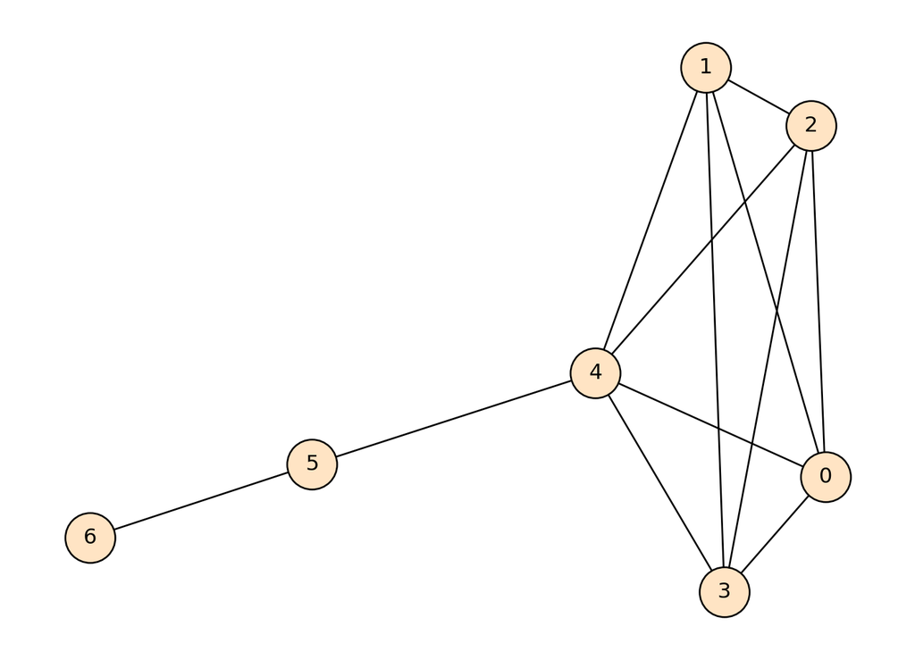

```python
#Define our network
G_betweenness_example = nx.Graph()
edges_list = [(0,1),(0,2),(0,3),(0,4),(1,2),(2,3),(3,4),(1,4),(2,4),(1,3),(4,5),(5,6)]
G_betweenness_example.add_edges_from(edges_list)
pos = nx.spring_layout(G_betweenness_example, seed=1000)

#Draw our graph
nx.draw(G_betweenness_example,pos=pos, with_labels=True, edgecolors="black", node_color="bisque", node_size=800)
```

Node $4$ serves as a *bridge* between nodes 5 and 6 to the rest of the nodes in the network. For a path to be drawn between nodes 6 or 5 to nodes 0,1,2,3, the path *must* go through node 4. Let’s calculate the betweenness centrality of this network, and label nodes by centrality:

[output not shown]

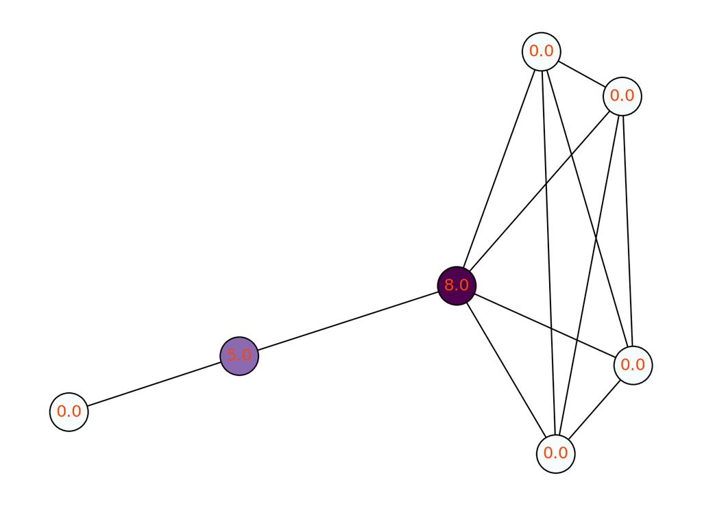

```python
#Define our network
G_betweenness_example = nx.Graph()
edges_list = [(0,1),(0,2),(0,3),(0,4),(1,2),(2,3),(3,4),(1,4),(2,4),(1,3),(4,5),(5,6)]
G_betweenness_example.add_edges_from(edges_list)
pos = nx.spring_layout(G_betweenness_example, seed=1000)

#Find the centrality values for our nodes
centrality = nx.betweenness_centrality(G_betweenness_example, normalized=False)
centrality_values = np.array(list(centrality.values()))
cmap="BuPu"

#Put labels on our network
labels = {}
for node in G_betweenness_example.nodes():
    labels[node] = centrality_values[node]


#Draw our graph using `nx.draw`
nx.draw(G_betweenness_example,pos=pos, node_color=centrality_values, edgecolors="black", cmap=cmap, node_size=800)
nx.draw_networkx_labels(G_betweenness_example, pos, labels=labels, font_color="orangered")
```

We can see that node 4 does indeed have the highest betweenness centrality. The values of 0 for nodes 0, 1, 2, 3 and 6 indicate that each node can reach every other node without passing through those nodes. The value of 5.0 for node 5 indicates that five nodes *must* pass through node 5 in order to reach another node.

### 4.5 Eigenvector centrality

**Eigenvector centrality** is a measure of the influence of a node in a network by considering not just how many connections it has (as we did with degree centrality), but also the importance of those connections: A node with high eigenvector centrality is connected to many nodes that themselves have high centrality, making it more influential in spreading information or resources. Unlike simpler measures like degree centrality, which only counts connections, eigenvector centrality looks at the overall structure of the network. It helps identify key players in a network who might not have the most connections but are well-connected to other important nodes.

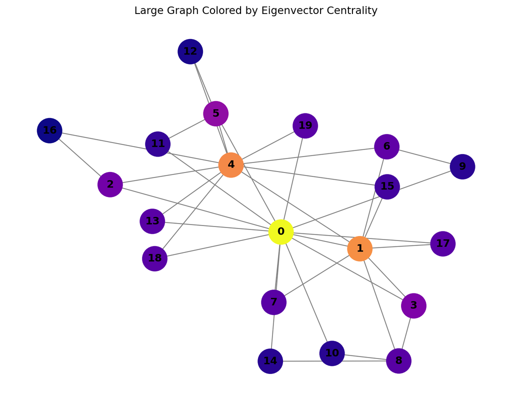

```
Node    Eigenvector Centrality
0   0.4856
1   0.3862
2   0.1964
3   0.2089
4   0.3801
5   0.2261
6   0.1801
7   0.1745
8   0.1718
9   0.1333
10  0.1316
11  0.1425
12  0.1214
13  0.1733
14  0.1316
15  0.1534
16  0.1154
17  0.1745
18  0.1733
19  0.1733
```

```python
# Create a larger network
G = nx.barabasi_albert_graph(n=20, m=2, seed=42)  # 20 nodes and each connects to 2

# Calculate eigenvector centrality
centrality = nx.eigenvector_centrality(G)

# Normalize values for coloring
centrality_values = np.array(list(centrality.values()))
norm_centrality = (centrality_values - centrality_values.min()) / (centrality_values.max() - centrality_values.min() + 1e-9)
cmap = plt.cm.plasma
color_map = [cmap(val) for val in norm_centrality]

# Draw the graph
plt.figure(figsize=(8, 6))
pos = nx.spring_layout(G, seed=42)
nx.draw(G, pos=pos, with_labels=True, node_color=color_map,
        node_size=800, font_weight='bold', edge_color='gray')
plt.title('Large Graph Colored by Eigenvector Centrality')
plt.tight_layout()
plt.show()

# Print node eigenvector centrality table
print("Node\tEigenvector Centrality")
for node in G.nodes():
    print(f"{node}\t{centrality[node]:.4f}")
```